# Fair share analysis following CERc method

Khoo Wei Yang

14/09/2023

In this analysis, I attempt to compare and analyse fair shares of climate mitigation effort following the Climate Equity Reference Framework. I use the [web-based calculator CERc](https://calculator.climateequityreference.org/) and its database last updated at May 2022, you can access the database [here](https://github.com/climateequityreferenceproject/cerc-coredb/tree/master). Fair share allocation is calculated as the fair amount of the total global emissions required to be reduced by each country. Allocation starts from Y2020. More details of the method can be found [here](https://climateequityreference.org/about-the-climate-equity-reference-project-effort-sharing-approach/) and [here](https://dataverse.harvard.edu/dataset.xhtml?persistentId=doi:10.7910/DVN/O3H22Z).

I intend to compare the fair shares of Indonesia, Thailand, US, and Malaysia as a cross-country reference for developed and developing countries. I also compare the NDCs of the countries against their fair share. I only look at the NDC GHG emissions target for Y2030. Net-zero emissions (of CO2 or other GHGs) by 2050 or later are not included.

I also look at fair shares of groupings and testing the fair share model for three equity principles: polluters pay, capable pay, and need-based principle CERF method explicitly assume individual needs-based exemption by using a development threshold, which exempts national income share considered below the threshold (annual USD 7500 PPP) from liable to contribute to climate mitigation.

Our settings are listed in the annex.

Caveat:  
1. The analysis did not account for difference in scope of GHG, most of the NDCs in comparison cover all of Kyoto GHGs (CO2, CH4, N2O, HFCs. PFCs, SF6, NF3) except for IDN (only CO2, CH4, N2O)  
2. I do not cover net-zero emissions for each country until 2050 due to lack of data.

# Getting the data ready

```r
# slice dataframe to fit
df.sliced <- df %>% slice(-(1:29))
names(df.sliced) <- df.sliced[1,]
df.sliced <- df.sliced[-1,]

df.lulucf.sliced <- df.lulucf %>% slice(-(1:29))
names(df.lulucf.sliced) <- df.lulucf.sliced[1,]
df.lulucf.sliced <- df.lulucf.sliced[-1,]

# extract for MYS, IDN, THA, and USA
fs.countries = c("MYS","IDN","THA","USA")
df.fs <- df.sliced %>%  filter(iso3 %in% fs.countries)
df.lulucf.fs <- df.lulucf.sliced %>%  filter(iso3 %in% fs.countries)

# assign correct object type to columns
df.fs[,c(3:21)] <- sapply(df.fs[c(3:21)], as.numeric)
str(df.fs)
```

```
'data.frame':   724 obs. of  21 variables:
 $ iso3                   : chr  "IDN" "IDN" "IDN" "IDN" ...
 $ country                : chr  "Indonesia" "Indonesia" "Indonesia" "Indonesia" ...
 $ year                   : num  1850 1851 1852 1853 1854 ...
 $ pop_mln                : num  20.2 20.4 20.7 20.9 21.2 ...
 $ gdp_blnUSDMER          : num  9.4 9.52 9.64 9.77 9.89 ...
 $ gdp_blnUSDPPP          : num  12.3 12.5 12.7 12.8 13 ...
 $ fossil_CO2_MtCO2       : num  0 0 0 0 0 0 0 0 0 0 ...
 $ LULUCF_MtCO2           : num  105 105 105 105 105 ...
 $ NonCO2_MtCO2e          : num  16.6 16.9 17.1 17.3 17.5 ...
 $ vol_rdxn_MtCO2         : num  0 0 0 0 0 0 0 0 0 0 ...
 $ allocation_MtCO2       : num  16.6 16.9 17.1 17.3 17.5 ...
 $ responsibility_MtCO2   : num  0.0142 0.0285 0.0431 0.0579 0.073 ...
 $ a1_dom_rdxn_MtCO2      : num  0 0 0 0 0 0 0 0 0 0 ...
 $ net_import_MtCO2       : num  0 0 0 0 0 0 0 0 0 0 ...
 $ capacity_blnUSDMER     : num  0.00804 0.00819 0.00834 0.00849 0.00864 ...
 $ rci                    : num  0.000175 0.000172 0.000171 0.000169 0.000168 ...
 $ pop_mln_above_dl       : num  0.00543 0.00553 0.00563 0.00573 0.00583 ...
 $ pop_mln_above_lux      : num  0.0000000107 0.0000000109 0.0000000111 0.0000000114 0.0000000116 0.0000000119 0.0000000121 0.0000000124 0.0000000127 0.000000013 ...
 $ lux_emiss_MtCO2        : num  0.000000138 0.000000141 0.000000145 0.000000148 0.000000151 0.000000154 0.000000158 0.000000161 0.000000164 0.000000168 ...
 $ lux_emiss_applied_MtCO2: num  0 0 0 0 0 0 0 0 0 0 ...
 $ kyoto_gap_MtCO2        : num  0 0 0 0 0 0 0 0 0 0 ...
```

```r
df.lulucf.fs[,c(3:21)] <- sapply(df.lulucf.fs[c(3:21)], as.numeric)
str(df.lulucf.fs)
```

```
'data.frame':   324 obs. of  21 variables:
 $ iso3                   : chr  "IDN" "IDN" "IDN" "IDN" ...
 $ country                : chr  "Indonesia" "Indonesia" "Indonesia" "Indonesia" ...
 $ year                   : num  1950 1951 1952 1953 1954 ...
 $ pop_mln                : num  69.5 70.8 72.3 73.8 75.5 ...
 $ gdp_blnUSDMER          : num  40.2 43.2 46.4 48.6 51 ...
 $ gdp_blnUSDPPP          : num  52.9 56.7 60.9 63.8 67 ...
 $ fossil_CO2_MtCO2       : num  12.6 12.1 16.4 16.9 19 ...
 $ LULUCF_MtCO2           : num  284 289 296 261 259 ...
 $ NonCO2_MtCO2e          : num  67.6 67.7 68.8 69.5 70.5 ...
 $ vol_rdxn_MtCO2         : num  0 0 0 0 0 0 0 0 0 0 ...
 $ allocation_MtCO2       : num  364 369 381 347 349 ...
 $ responsibility_MtCO2   : num  0.703 1.547 2.57 3.722 4.87 ...
 $ a1_dom_rdxn_MtCO2      : num  0 0 0 0 0 0 0 0 0 0 ...
 $ net_import_MtCO2       : num  0 0 0 0 0 0 0 0 0 0 ...
 $ capacity_blnUSDMER     : num  0.0777 0.1 0.1287 0.1469 0.1685 ...
 $ rci                    : num  0.000138 0.00015 0.00016 0.00017 0.000175 ...
 $ pop_mln_above_dl       : num  0.0486 0.0614 0.0776 0.0877 0.0997 ...
 $ pop_mln_above_lux      : num  0.000000188 0.000000278 0.000000411 0.000000502 0.000000619 0.000000822 0.000000859 0.00000081 0.0000011 0.00000073 ...
 $ lux_emiss_MtCO2        : num  0.000013 0.0000184 0.0000266 0.0000284 0.0000336 0.0000437 0.0000449 0.000042 0.0000536 0.0000367 ...
 $ lux_emiss_applied_MtCO2: num  0 0 0 0 0 0 0 0 0 0 ...
 $ kyoto_gap_MtCO2        : num  0 0 0 0 0 0 0 0 0 0 ...
```

# Computing the NDCs

### NDC for Y2030

Some information on compared NDCs.

**IDN**  
BAU scenario - 2869 MtCO2e  
31.89% unconditional  
43.20% conditional

**THA** [NDC 2022](https://unfccc.int/sites/default/files/NDC/2022-11/Thailand%202nd%20Updated%20NDC.pdf)  
BAU scenario - 555 MtCO2e  
30% unconditional below BAU scenario  
40% conditional

**USA** [NDC 2021](https://unfccc.int/sites/default/files/NDC/2022-06/United%20States%20NDC%20April%2021%202021%20Final.pdf)  
2005 levels net emissions - 6635 MtCO2e  
50 -52% reduction below 2005 net emissions levels

**MYS** [source: [NC](https://unfccc.int/sites/default/files/resource/Malaysia%20NC3%20BUR2_final%20high%20res.pdf), [BUR4](https://unfccc.int/sites/default/files/resource/MY%20BUR4_2022.pdf)]  
ttl emissions 2005 - 250.044  
ttl BAU emissions 2030 - 530.29108 (549.53451) # (incl. LULUCF emissions only no removal)  
net emissions 2005 - 52.967  
net BAU emissions 2030 - 302.88559  
GDP 2005 (cst 2015) - 729.82 b MYR  
GDP 2022 - 1507.31 b MYR  
GDP 2030 - 2143.55 b MYR  
45% (EI2005 - EI2030)

Calculating the NDC for IDN, THA, and USA is pretty straightforward as the emissions reduction quotient is relative to a reported annual or BAU scenario emissions level.

Because all NDC targets in our comparison covers “economy-wide” emissions, LULUCF emi/rem and Non-CO2 are included in the BAU.

```r
## ---  NDC - fair share comparisons --- ##

#### compute NDC - emissions allocation

NDC.uncon.idn = 2869*(1-.3189)
NDC.con.idn = 2869*(1-.4320)
NDC.uncon.tha = 555*(1-.3)
NDC.con.tha = 555*(1-.4)
NDC.lower.US = 6635*(1-.5)
NDC.upper.US = 6635*(1-.52)

#### compute NDC - emissions reduction

NDC.rdxn.uncon.idn = 2869*.3189
NDC.rdxn.con.idn = 2869*.4320
NDC.rdxn.uncon.tha = 555*.3
NDC.rdxn.con.tha = 555*.4
NDC.rdxn.lower.US = 6635*.5
NDC.rdxn.upper.US = 6635*.52
```

Malaysian NDC is based on emissions intensity relative to base year, we can work backwards to obtain the NDC target emissions level at 2030, which requires knowledge of base year emissions and GDP as well as future GDP. I project GDP based on IMF World Economic Outlook 2023’s forecast of 4.5% annual growth (CAGR for 8 years). We use 2015 constant price GDP for 2005 and 2022 from IMF’s database. For country reported 2005 emissions, we use most recent BUR4 updated figures. This is different from the earlier NC3 figures. Of course, to rebase this to CERF baseline, we will need to work backwards with CERF 2005 emissions data.

```r
#### MYS emissions intensity-based NDC calc

# set up CAGR and EI functions #

CAGR_FV <- function(CAGR, present_value, yrs) {
  final_value = present_value * (CAGR / 100 + 1)^yrs
  return(final_value)
}

EI_Ef <- function(Ei, delta) {
  # Ef = emissions intensity at final year, 2030
  # Ei = emissions intensity at initial year, 2005
  # delta = difference between compared final and initial year, 0.45
  Ef = Ei*(delta + 1)
  return(Ef)
}

## find MYS NDC emissions level

GDP2005<- 729.82
GDP2030 <- CAGR_FV(4.5, 1507.31, 8) # find GDP2030 based on WEO forecast 4.5% growth rate

BUR4.emi2005 <- 250.044

EI2005 <- BUR4.emi2005/GDP2005
EI2030 <- EI_Ef(EI2005, -0.45) # find emissions intensity based on known 2005 figures

BUR4.emi2030 <- EI2030*GDP2030 # find absolute 2030 emissions

NDC.MYS <- BUR4.emi2030 # NDC 2030 emissions level is based on EI 45% lower than 2005

BUR4.netemi2005 <- 52.967

EI2005.lulucf <- BUR4.netemi2005/GDP2005 # find emissions intensity based on known 2005 netted figures
EI2030.lulucf <- EI_Ef(EI2005.lulucf, -0.45) # find emissions intensity based on known 2005 netted figures

BUR4.netemi2030 <- EI2030.lulucf*GDP2030 # find absolute 2030 emissions

NDC.MYS.lulucf <- BUR4.netemi2030 # NDC 2030 emissions level is based on EI 45% lower than 2005

#### compute NDC - emissions reduction for MYS

NDC.rdxn.MYS <- 530.29108 - BUR4.emi2030 # BUR BAU
NDC.rdxn.MYS.lulucf <- 302.88559 - BUR4.netemi2030
```

```r
## --- create comparison table --- ##

df.compare <- df.fs

## --- add NDC column for all countries --- ##
# create base and net-CO2 emissions line [fossil CO2 +- LULUCF removals]

df.compare <- df.compare %>% mutate(base_emissions_mtco2e = fossil_CO2_MtCO2+NonCO2_MtCO2e)
df.compare <- df.compare %>% mutate(net_emissions_mtco2e = fossil_CO2_MtCO2+NonCO2_MtCO2e+LULUCF_MtCO2)

# add NDC value to new column

df.compare <- df.compare %>%
  mutate(NDCuncon_emissions_target_mtco2e =
           case_when(
                      iso3 == "IDN" & year == 2030 ~ NDC.uncon.idn,
                      iso3 == "THA" & year == 2030 ~ NDC.uncon.tha,
                      iso3 == "USA" & year == 2030 ~ NDC.lower.US,
                      iso3 == "MYS" & year == 2030 ~ NDC.MYS,
                      .default = NA)
         )
df.compare <- df.compare %>%
  mutate(NDCcon_emissions_target_mtco2e =
           case_when(
             iso3 == "IDN" & year == 2030 ~ NDC.con.idn,
             iso3 == "THA" & year == 2030 ~ NDC.con.tha,
             iso3 == "USA" & year == 2030 ~ NDC.upper.US,
             .default = NA)
        )
```

# Rebasing the NDCs for comparability

I now have to rebase the NDC quotients from the country report BAU to CERF baseline, which uses the PRIMP-hist dataset. Deeper technical documentation of the dataset is found here.

I do this because the BAU reported by countries can be different from the CERF baseline, which the calculator uses to derive fair share. By comparing the targetted emissions reduction level relative to baseline with fair share reduction level relative to another baseline can be misguiding. Because we do not perform calculations of fair share allocation based on BAU due to the absence of country reported data on deep historical emissions (up to 1850, which CERF use), I do this to minimize error in comparability.

This rebase exercise follows two approaches:  
1. I rebase the NDC to the CERF baseline without LULUCF, this is the standard method that the calculator uses. As historical LULUCF data is highly variable and was ceased being published by PRIMAP-hist due to concerns over reliability, the standard calculator only considers total GHG emissions excluding LULUCF.  
2. I rebase the NDC to CERF baseline incl. of LULUCF. This is due to the comparability issue with NDCs which considers LULUCF emi/rem.

### Approach 1

```r
## --- Approach 1 rebase --- ##

## rebase NDC to total emissions excl. LULUCF baseline

### IDN [31.89% - 43.20% below BAU]
NDC.rebase1.idn.uncon <- df.compare[df.compare$iso3 == "IDN" & df.compare$year == 2030, # rebase uncon NDC to CERc BAU in 2030
                                    "base_emissions_mtco2e"]*(1-.3189)
NDC.rebase1.idn.con <- df.compare[df.compare$iso3 == "IDN" & df.compare$year == 2030, # rebase con NDC to CERc BAU in 2030
                                    "base_emissions_mtco2e"]*(1-.4320)

### THA [30% - 40% below BAU]
NDC.rebase1.tha.uncon <- df.compare[df.compare$iso3 == "THA" & df.compare$year == 2030, # rebase uncon NDC to CERc BAU in 2030
                                    "base_emissions_mtco2e"]*(1-.30)
NDC.rebase1.tha.con <- df.compare[df.compare$iso3 == "THA" & df.compare$year == 2030, # rebase con NDC to CERc BAU in 2030
                                  "base_emissions_mtco2e"]*(1-.40)

### USA [30% - 40% below BAU]
NDC.rebase1.usa.lower <- df.compare[df.compare$iso3 == "USA" & df.compare$year == 2030, # rebase lower NDC to CERc BAU in 2030
                                    "base_emissions_mtco2e"]*(1-.50)
NDC.rebase1.usa.upper <- df.compare[df.compare$iso3 == "USA" & df.compare$year == 2030, # rebase upper NDC to CERc BAU in 2030
                                  "base_emissions_mtco2e"]*(1-.52)

### MYS [45% below 2005 EI]
#### rebase EI2005 to CERc emissions baseline
EI2005cerc <- df.compare[df.compare$iso3 == "MYS" & df.compare$year == 2005, "base_emissions_mtco2e"]/GDP2005
EI2030cerc <- EI_Ef(EI2005cerc, -0.45) # find emissions intensity based on CERC 2005 figures

NDC.rebase1.mys <- EI2030cerc*GDP2030

### MYS [45% below 2005 EI]
#### rebase EI2005 to CERc emissions baseline
EI2005cerc <- df.compare[df.compare$iso3 == "MYS" & df.compare$year == 2005, "base_emissions_mtco2e"]/GDP2005
EI2030cerc <- EI_Ef(EI2005cerc, -0.45) # find emissions intensity based on CERC 2005 figures

NDC.rebase1.mys <- EI2030cerc*GDP2030

## add column with rebased NDC figures

df.compare <- df.compare %>%
  mutate(rb1_NDCuncon_mtco2e =
           case_when(
             iso3 == "IDN" & year == 2030 ~ NDC.rebase1.idn.uncon,
             iso3 == "THA" & year == 2030 ~ NDC.rebase1.tha.uncon,
             iso3 == "USA" & year == 2030 ~ NDC.rebase1.usa.lower,
             iso3 == "MYS" & year == 2030 ~ NDC.rebase1.mys,
             .default = NA)
  )
df.compare <- df.compare %>%
  mutate(rb1_NDCcon_mtco2e =
           case_when(
             iso3 == "IDN" & year == 2030 ~ NDC.rebase1.idn.con,
             iso3 == "THA" & year == 2030 ~ NDC.rebase1.tha.con,
             iso3 == "USA" & year == 2030 ~ NDC.rebase1.usa.upper,
             .default = NA)
  )
```

Plot the emissions allocation graph.

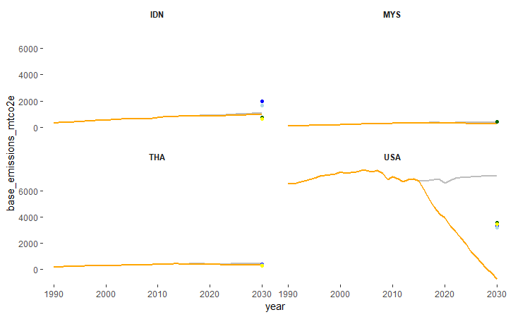

```r
## plot preview

ggplot(df.compare) +
  facet_wrap(~iso3, scales = "free") +
  geom_path(aes(x = year, y = base_emissions_mtco2e),
            colour = "grey",
            linewidth = 1) +
  geom_path(aes(x = year, y = allocation_MtCO2),
            colour = "orange",
            linewidth = 1) +
  geom_point(aes(x = year, y = NDCuncon_emissions_target_mtco2e),
             colour = "blue",
             size = 1.5) +
  geom_point(aes(x = year, y = NDCcon_emissions_target_mtco2e),
             colour = "lightblue",
             size = 1.5) +
  geom_point(aes(x = year, y = rb1_NDCuncon_mtco2e),
             colour = "darkgreen",
             size = 1.5) +
  geom_point(aes(x = year, y = rb1_NDCcon_mtco2e),
             colour = "yellow",
             size = 1.5) +
  scale_x_continuous(limit = c(1990,2030)) +
  facet_wrap(vars(iso3)) +
    theme(panel.background = element_blank(),
          panel.grid = element_blank(),
          strip.background = element_blank(),
          strip.text = element_text(face = "bold"))
```

### Approach 2

For the second approach we rebase the emissions reduction target quotient to the CERF baseline inclusive of LULUCF emissions/removal. This method is discontinued online but the database is still accessible.

```r
## --- Approach 2 --- ##

## national allocations are calculated as the difference between the national baseline
## and national share of the global emissions reduction obligation
## RCI = national rdx/global rdx
## national rdx = RCI/global rdx
# global rdx in 2030 = 29422.99 MtCO2e

# use lulucf-based dataset
## create same comparison table

df.compare.lulucf <- df.lulucf.fs

## --- add NDC column for all countries --- ##
# create base and net-CO2 emissions line [fossil CO2 +- LULUCF removals]

df.compare.lulucf <- df.compare.lulucf %>% mutate(base_netemissions_mtco2e = fossil_CO2_MtCO2+NonCO2_MtCO2e+LULUCF_MtCO2)

## add NDC to new columns in lulucf compare dataframe

df.compare.lulucf <- df.compare.lulucf %>%
  mutate(NDCuncon_emissions_target_mtco2e =
           case_when(
             iso3 == "IDN" & year == 2030 ~ NDC.uncon.idn,
             iso3 == "THA" & year == 2030 ~ NDC.uncon.tha,
             iso3 == "USA" & year == 2030 ~ NDC.lower.US,
             iso3 == "MYS" & year == 2030 ~ NDC.MYS.lulucf, # replace MYS NDC with net emissions adjusted figure
             .default = NA)
  )
df.compare.lulucf <- df.compare.lulucf %>%
  mutate(NDCcon_emissions_target_mtco2e =
           case_when(
             iso3 == "IDN" & year == 2030 ~ NDC.con.idn,
             iso3 == "THA" & year == 2030 ~ NDC.con.tha,
             iso3 == "USA" & year == 2030 ~ NDC.upper.US,
             .default = NA)
  )
```

```r
## rebase NDC to total emissions excl. LULUCF baseline

### IDN [31.89% - 43.20% below BAU]
NDC.rebase2.idn.uncon <- df.compare.lulucf[df.compare.lulucf$iso3 == "IDN" & df.compare.lulucf$year == 2030, # rebase uncon NDC to CERc BAU in 2030
                                    "base_netemissions_mtco2e"]*(1-.3189)
NDC.rebase2.idn.con <- df.compare.lulucf[df.compare.lulucf$iso3 == "IDN" & df.compare.lulucf$year == 2030, # rebase con NDC to CERc BAU in 2030
                                  "base_netemissions_mtco2e"]*(1-.4320)

### THA [30% - 40% below BAU]
NDC.rebase2.tha.uncon <- df.compare.lulucf[df.compare.lulucf$iso3 == "THA" & df.compare.lulucf$year == 2030, # rebase uncon NDC to CERc BAU in 2030
                                    "base_netemissions_mtco2e"]*(1-.30)
NDC.rebase2.tha.con <- df.compare.lulucf[df.compare.lulucf$iso3 == "THA" & df.compare.lulucf$year == 2030, # rebase con NDC to CERc BAU in 2030
                                  "base_netemissions_mtco2e"]*(1-.40)

### USA [30% - 40% below BAU]
NDC.rebase2.usa.lower <- df.compare.lulucf[df.compare.lulucf$iso3 == "USA" & df.compare.lulucf$year == 2030, # rebase lower NDC to CERc BAU in 2030
                                    "base_netemissions_mtco2e"]*(1-.50)
NDC.rebase2.usa.upper <- df.compare.lulucf[df.compare.lulucf$iso3 == "USA" & df.compare.lulucf$year == 2030, # rebase upper NDC to CERc BAU in 2030
                                    "base_netemissions_mtco2e"]*(1-.52)

### MYS [45% below 2005 EI]
#### rebase EI2005 to CERc emissions baseline
EI2005cerc.lulucf <- df.compare.lulucf[df.compare.lulucf$iso3 == "MYS" & df.compare.lulucf$year == 2005, "base_netemissions_mtco2e"]/GDP2005
EI2030cerc.lulucf <- EI_Ef(EI2005cerc.lulucf, -0.45) # find emissions intensity based on CERC 2005 figures

NDC.rebase2.mys <- EI2030cerc.lulucf*GDP2030

## add column with rebased NDC figures

df.compare.lulucf <- df.compare.lulucf %>%
  mutate(rb2_NDCuncon_mtco2e =
           case_when(
             iso3 == "IDN" & year == 2030 ~ NDC.rebase2.idn.uncon,
             iso3 == "THA" & year == 2030 ~ NDC.rebase2.tha.uncon,
             iso3 == "USA" & year == 2030 ~ NDC.rebase2.usa.lower,
             iso3 == "MYS" & year == 2030 ~ NDC.rebase2.mys,
             .default = NA)
  )
df.compare.lulucf <- df.compare.lulucf %>%
  mutate(rb2_NDCcon_mtco2e =
           case_when(
             iso3 == "IDN" & year == 2030 ~ NDC.rebase2.idn.con,
             iso3 == "THA" & year == 2030 ~ NDC.rebase2.tha.con,
             iso3 == "USA" & year == 2030 ~ NDC.rebase2.usa.upper,
             .default = NA)
  )
```

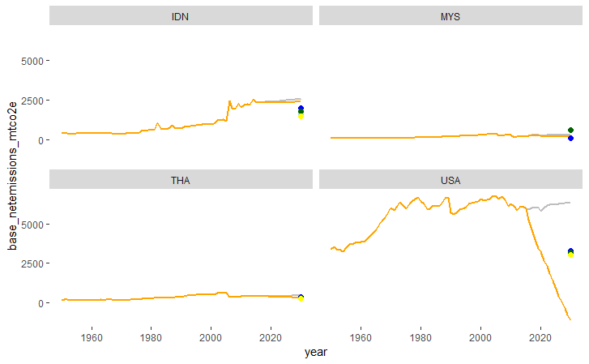

```r
## --- plot preview --- ##

ggplot(df.compare.lulucf) +
  geom_path(aes(x = year, y = base_netemissions_mtco2e),
            colour = "grey",
            linewidth= 1) +
  geom_path(aes(x = year, y = allocation_MtCO2),
            colour = "orange",
            linewidth= 1) +
  geom_point(aes(x = year, y = NDCuncon_emissions_target_mtco2e),
             colour = "blue",
             size = 2) +
  geom_point(aes(x = year, y = NDCcon_emissions_target_mtco2e),
             colour = "lightblue",
             size = 2) +
  geom_point(aes(x = year, y = rb2_NDCuncon_mtco2e),
             colour = "darkgreen",
             size = 2) +
  geom_point(aes(x = year, y = rb2_NDCcon_mtco2e),
             colour = "yellow",
             size = 2) +
  theme(panel.background = element_blank(),
        panel.grid = element_blank(),
        ) +
  facet_wrap(vars(iso3))
```

# Wrapping up the comparison

I now write the results into neat comparative tables and graphics.

First we create the table for comparison without lulucf.

```r
## --- output reduction levels for fair share and NDCs --- ##

# total emissions excl. LULUCF baseline for 2030
## fair share reductions
fs.rdxn.idn <- df.compare[df.compare$iso3 == "IDN" & df.compare$year == "2030", "base_emissions_mtco2e"] -
  df.compare[df.compare$iso3 == "IDN" & df.compare$year == "2030", "allocation_MtCO2"]
fs.rdxn.tha <- df.compare[df.compare$iso3 == "THA" & df.compare$year == "2030", "base_emissions_mtco2e"] -
  df.compare[df.compare$iso3 == "THA" & df.compare$year == "2030", "allocation_MtCO2"]
fs.rdxn.usa <- df.compare[df.compare$iso3 == "USA" & df.compare$year == "2030", "base_emissions_mtco2e"] -
  df.compare[df.compare$iso3 == "USA" & df.compare$year == "2030", "allocation_MtCO2"]
fs.rdxn.mys <- df.compare[df.compare$iso3 == "MYS" & df.compare$year == "2030", "base_emissions_mtco2e"] -
  df.compare[df.compare$iso3 == "MYS" & df.compare$year == "2030", "allocation_MtCO2"]

##* recall NDC reductions calculations from above
##* use rebase 1

NDC.rdxn.uncon.rebase1.idn <- df.compare[df.compare$iso3 == "IDN" & df.compare$year == "2030", "base_emissions_mtco2e"] - NDC.rebase1.idn.uncon
NDC.rdxn.con.rebase1.idn <- df.compare[df.compare$iso3 == "IDN" & df.compare$year == "2030", "base_emissions_mtco2e"] - NDC.rebase1.idn.con
NDC.rdxn.uncon.rebase1.tha <- df.compare[df.compare$iso3 == "THA" & df.compare$year == "2030", "base_emissions_mtco2e"] - NDC.rebase1.tha.uncon
NDC.rdxn.con.rebase1.tha <- df.compare[df.compare$iso3 == "THA" & df.compare$year == "2030", "base_emissions_mtco2e"] - NDC.rebase1.tha.con
NDC.rdxn.lower.rebase1.usa <- df.compare[df.compare$iso3 == "USA" & df.compare$year == "2030", "base_emissions_mtco2e"] - NDC.rebase1.usa.lower
NDC.rdxn.upper.rebase1.usa <- df.compare[df.compare$iso3 == "USA" & df.compare$year == "2030", "base_emissions_mtco2e"] - NDC.rebase1.usa.upper
NDC.rdxn.rebase1.mys <- df.compare[df.compare$iso3 == "MYS" & df.compare$year == "2030", "base_emissions_mtco2e"] - NDC.rebase1.mys

# output dataframe of NDC - rebase1 - fair share comparisons
fairshare.output <- data.frame(country  = c("IDN", "THA", "USA","MYS"),
                 NDC.emi.rdxn.uncon = c(NDC.rdxn.uncon.idn, NDC.rdxn.uncon.tha, NDC.rdxn.lower.US, NDC.rdxn.MYS),
                 NDC.emi.rdxn.con = c(NDC.rdxn.con.idn, NDC.rdxn.con.tha, NDC.rdxn.upper.US, NDC.rdxn.MYS),
                 NDC.rebase.uncon = c(NDC.rdxn.uncon.rebase1.idn,NDC.rdxn.uncon.rebase1.tha,NDC.rdxn.lower.rebase1.usa,NDC.rdxn.rebase1.mys),
                 NDC.rebase.con = c(NDC.rdxn.con.rebase1.idn,NDC.rdxn.con.rebase1.tha,NDC.rdxn.upper.rebase1.usa,NA),
                 fairshare.rdxn = c(fs.rdxn.idn, fs.rdxn.tha, fs.rdxn.usa, fs.rdxn.mys)
                 )
print(fairshare.output)
```

| country | NDC.emi.rdxn.uncon | NDC.emi.rdxn.con | NDC.rebase.uncon | NDC.rebase.con | fairshare.rdxn |
| --- | --- | --- | --- | --- | --- |
| IDN | 914.9241 | 1239.4080 | 351.43312 | 476.0712 | 130.4373 |
| THA | 166.5000 | 222.0000 | 135.14380 | 180.1917 | 102.9613 |
| USA | 3317.5000 | 3450.2000 | 3586.79931 | 3730.2713 | 7912.0712 |
| MYS | 126.3702 | 126.3702 | -17.54272 | NA | 127.0594 |

Then we do the same for comparison with lulucf.

```r
## total emissions incl. LULUCF baseline for 2030
fs.rdxn.idn.lulucf <- df.compare.lulucf[df.compare.lulucf$iso3 == "IDN" & df.compare.lulucf$year == "2030", "base_netemissions_mtco2e"] -
  df.compare.lulucf[df.compare.lulucf$iso3 == "IDN" & df.compare.lulucf$year == "2030", "allocation_MtCO2"]
fs.rdxn.tha.lulucf <- df.compare.lulucf[df.compare.lulucf$iso3 == "THA" & df.compare.lulucf$year == "2030", "base_netemissions_mtco2e"] -
  df.compare.lulucf[df.compare.lulucf$iso3 == "THA" & df.compare.lulucf$year == "2030", "allocation_MtCO2"]
fs.rdxn.usa.lulucf <- df.compare.lulucf[df.compare.lulucf$iso3 == "USA" & df.compare.lulucf$year == "2030", "base_netemissions_mtco2e"] -
  df.compare.lulucf[df.compare.lulucf$iso3 == "USA" & df.compare.lulucf$year == "2030", "allocation_MtCO2"]
fs.rdxn.mys.lulucf <- df.compare.lulucf[df.compare.lulucf$iso3 == "MYS" & df.compare.lulucf$year == "2030", "base_netemissions_mtco2e"] -
  df.compare.lulucf[df.compare.lulucf$iso3 == "MYS" & df.compare.lulucf$year == "2030", "allocation_MtCO2"]

##* recall NDC reductions /w netted emissions calculations from above
##* BAU for IDN, THA, USA should be the same
##* use rebase2

NDC.rdxn.uncon.rebase2.idn <- df.compare.lulucf[df.compare.lulucf$iso3 == "IDN" & df.compare.lulucf$year == "2030", "base_netemissions_mtco2e"] - NDC.rebase2.idn.uncon
NDC.rdxn.con.rebase2.idn <- df.compare.lulucf[df.compare.lulucf$iso3 == "IDN" & df.compare.lulucf$year == "2030", "base_netemissions_mtco2e"] - NDC.rebase2.idn.con
NDC.rdxn.uncon.rebase2.tha <- df.compare.lulucf[df.compare.lulucf$iso3 == "THA" & df.compare.lulucf$year == "2030", "base_netemissions_mtco2e"] - NDC.rebase2.tha.uncon
NDC.rdxn.con.rebase2.tha <- df.compare.lulucf[df.compare.lulucf$iso3 == "THA" & df.compare.lulucf$year == "2030", "base_netemissions_mtco2e"] - NDC.rebase2.tha.con
NDC.rdxn.lower.rebase2.usa <- df.compare.lulucf[df.compare.lulucf$iso3 == "USA" & df.compare.lulucf$year == "2030", "base_netemissions_mtco2e"] - NDC.rebase2.usa.lower
NDC.rdxn.upper.rebase2.usa <- df.compare.lulucf[df.compare.lulucf$iso3 == "USA" & df.compare.lulucf$year == "2030", "base_netemissions_mtco2e"] - NDC.rebase2.usa.upper
NDC.rdxn.rebase2.mys <- df.compare.lulucf[df.compare.lulucf$iso3 == "MYS" & df.compare.lulucf$year == "2030", "base_netemissions_mtco2e"] - NDC.rebase2.mys

# output dataframe of NDC - rebase2 - fair share comparisons
fairshare.output.lulucf <- data.frame(country  = c("IDN", "THA", "USA","MYS"),
                               NDC.emi.rdxn.uncon = c(NDC.rdxn.uncon.idn, NDC.rdxn.uncon.tha, NDC.rdxn.lower.US, NDC.rdxn.MYS),
                               NDC.emi.rdxn.con = c(NDC.rdxn.con.idn, NDC.rdxn.con.tha, NDC.rdxn.upper.US, NDC.rdxn.MYS),
                               NDC.rebase.uncon = c(NDC.rdxn.uncon.rebase2.idn,NDC.rdxn.uncon.rebase2.tha,NDC.rdxn.lower.rebase2.usa,NDC.rdxn.rebase2.mys),
                               NDC.rebase.con = c(NDC.rdxn.con.rebase2.idn,NDC.rdxn.con.rebase2.tha,NDC.rdxn.upper.rebase2.usa,NA),
                                fairshare.rdxn = c(fs.rdxn.idn.lulucf, fs.rdxn.tha.lulucf, fs.rdxn.usa.lulucf, fs.rdxn.mys.lulucf)
                               )

print(fairshare.output.lulucf)
```

| country | NDC.emi.rdxn.uncon | NDC.emi.rdxn.con | NDC.rebase.uncon | NDC.rebase.con | fairshare.rdxn |
| --- | --- | --- | --- | --- | --- |
| IDN | 914.9241 | 1239.4080 | 824.0431 | 1116.2955 | 210.6889 |
| THA | 166.5000 | 222.0000 | 137.3537 | 183.1383 | 126.4974 |
| USA | 3317.5000 | 3450.2000 | 3181.6546 | 3308.9208 | 7489.2181 |
| MYS | 126.3702 | 126.3702 | -270.6196 | NA | 135.9091 |

I now plot a simple point graph for both graphs.

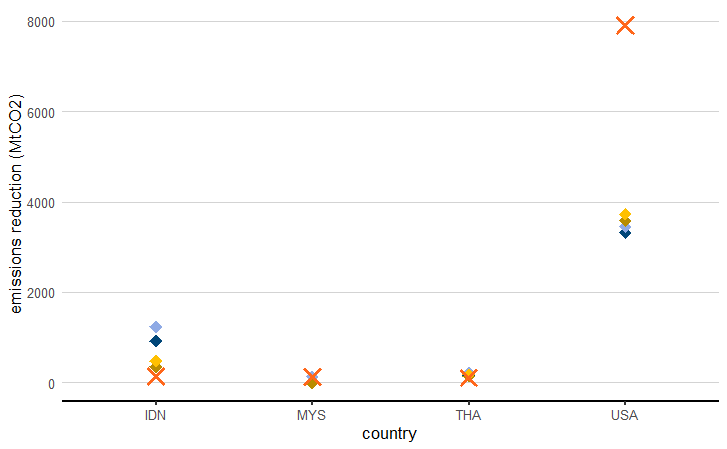

```r
## --- plot preview --- ##

# without lulucf
ggplot(fairshare.output) +
  geom_point(aes(x = country, y = NDC.emi.rdxn.uncon),
              colour = "#004678",
              shape = 18,
              size = 4) +
  geom_point(aes(x = country, y = NDC.emi.rdxn.con),
             colour = "#8FAAE5",
             shape = 18,
             size = 4) +
  geom_point(aes(x = country, y = NDC.rebase.uncon),
             colour = "#B88C00",
             shape = 18,
             size = 4) +
  geom_point(aes(x = country, y = NDC.rebase.con),
             colour = "#FFC000",
             shape = 18,
             size = 4) +
  geom_point(aes(x = country, y = fairshare.rdxn),
             colour = "#FF671B",
             shape = 4,
             stroke = 2,
             size = 4) +
  labs(x = "country",
       y = "emissions reduction (MtCO2)") +
  theme(panel.background = element_blank(),
        panel.grid.major.y = element_line(linewidth = 0.5,
                                          colour = "lightgrey"),
        panel.grid.major.x = element_blank(),
        axis.line.x = element_line(linewidth = 1),
        axis.ticks.x = element_line(linewidth = 1),
        axis.ticks.y = element_blank(),
        text = element_text(family = "Arial",
                            size = 12))
```

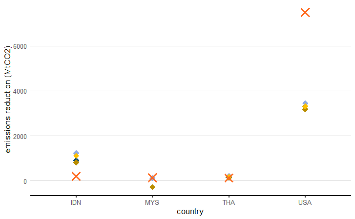

```r
# with lulucf

ggplot(fairshare.output.lulucf) +
  geom_point(aes(x = country, y = NDC.emi.rdxn.uncon),
             colour = "#004678",
             shape = 18,
             size = 4) +
  geom_point(aes(x = country, y = NDC.emi.rdxn.con),
             colour = "#8FAAE5",
             shape = 18,
             size = 4) +
  geom_point(aes(x = country, y = NDC.rebase.uncon),
             colour = "#B88C00",
             shape = 18,
             size = 4) +
  geom_point(aes(x = country, y = NDC.rebase.con),
             colour = "#FFC000",
             shape = 18,
             size = 4) +
  geom_point(aes(x = country, y = fairshare.rdxn),
             colour = "#FF671B",
             shape = 4,
             stroke = 2,
             size = 4) +
  labs(x = "country",
       y = "emissions reduction (MtCO2)") +
  theme(panel.background = element_blank(),
        panel.grid.major.y = element_line(linewidth = 0.5,
                                          colour = "lightgrey"),
        panel.grid.major.x = element_blank(),
        axis.line.x = element_line(linewidth = 1),
        axis.ticks.x = element_line(linewidth = 1),
        axis.ticks.y = element_blank(),
        text = element_text(family = "Arial",
                            size = 12))
```

# Analysis

A fair NDC target would align with fair share, a more ambitious NDC target would be above the emissions reduction required by fair share.

To put things into perspective, US overall aimed far less ambitious than it ought to. The country’s NDC target is off the their fair share mark by around 4000 MtCo2e in both scenarios. This means the country ought to ramp up immensely its ambition to equitably recompense for the responsibility it holds over global warming.